# Eurovision Song Contest country profile

2025-05-02

# Switzerland

## Participation and successes

Switzerland has participated in the Eurovision Song Contest 63 times. It made it to the final round 52 times - that’s 82.5%.

Switzerland has won 2 times. Its most successful performance took place in the 1958 final, when the country got 24% of all possible points.

## Final place distribution

Here’s how many times Switzerland earned a particular place in the final round of Eurovision:

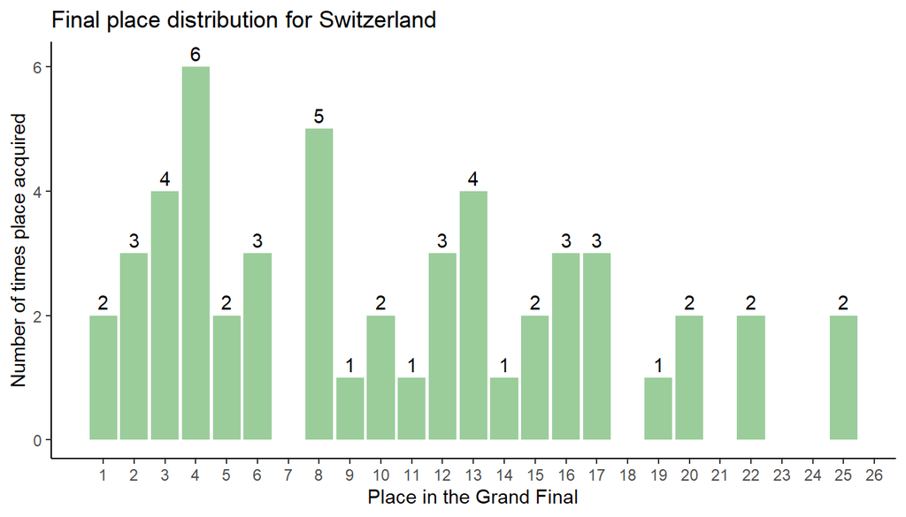

## Loyal besties

Below are the countries that have NEVER given Switzerland zero points. The bar chart shows the lowest score those countries gave Switzerland instead.

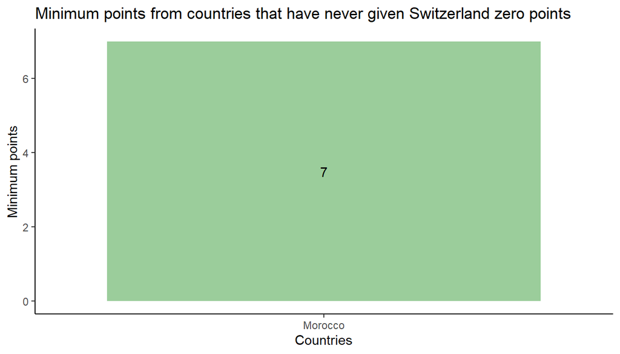

## Only zeros

On the other hand, here are the countries that have never given Switzerland more than zero points.

```
## Just kidding! No country would do something like that to Switzerland
```

## Birds of a feather sing together

The European Broadcasting Union started separating televote (votes cast by audience) and jury vote (votes cast by official representatives of each participating country) in 2016. Below is a chart that shows top five countries whose public voted for Switzerland and top five countries that Switzerland public voted for the most between 2016 and 2024:

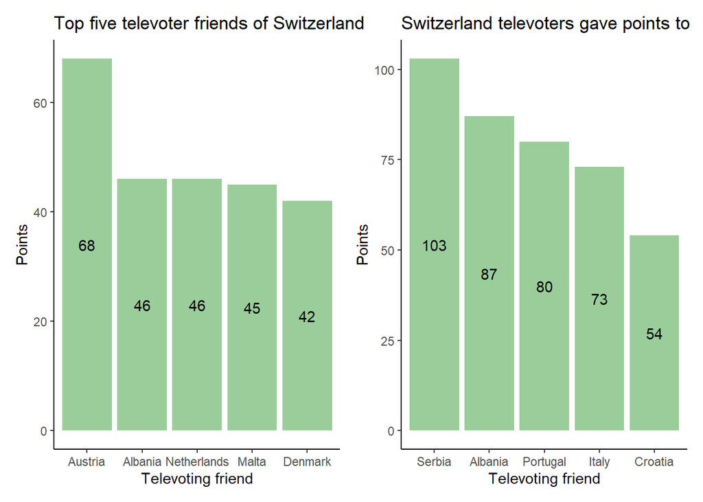

Below is a chart that shows top five countries whose jury voted for Switzerland and top five countries that Switzerland jury voted for the most between 2016 and 2024:

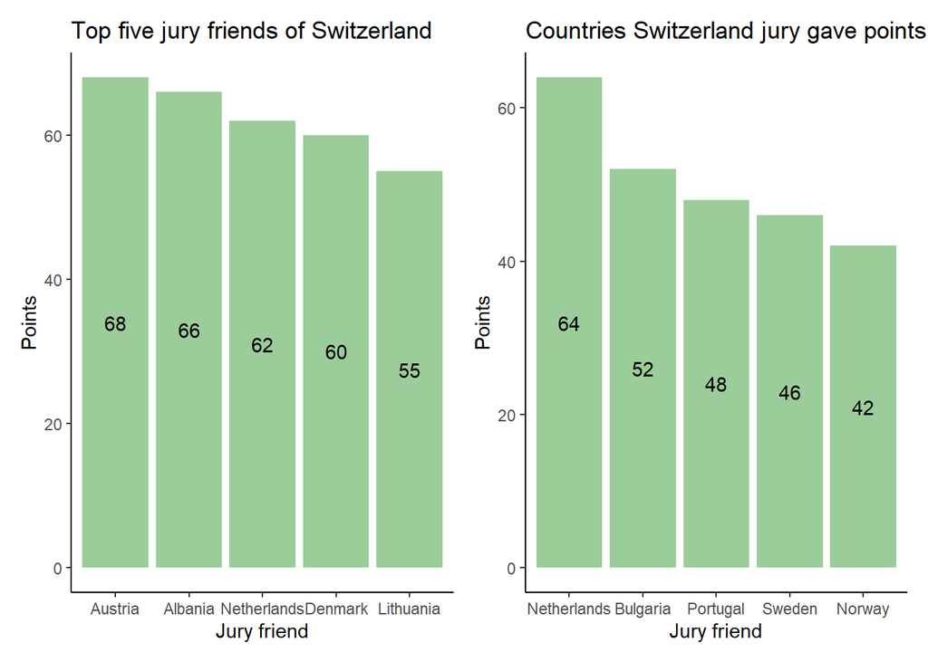

Finally, here is a chart that shows overall (televote and jury vote combined) top five countries that voted for Switzerland and top five countries that Switzerland voted for the most between 1957 and 2024:

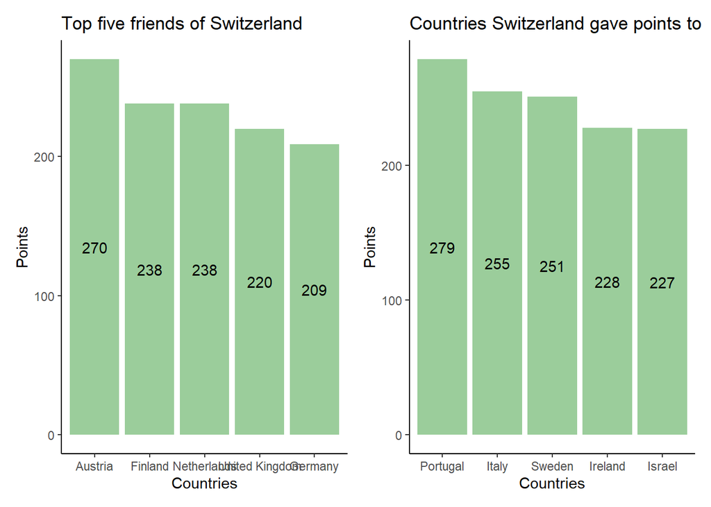